# BMIN503/EPID600 Project Template

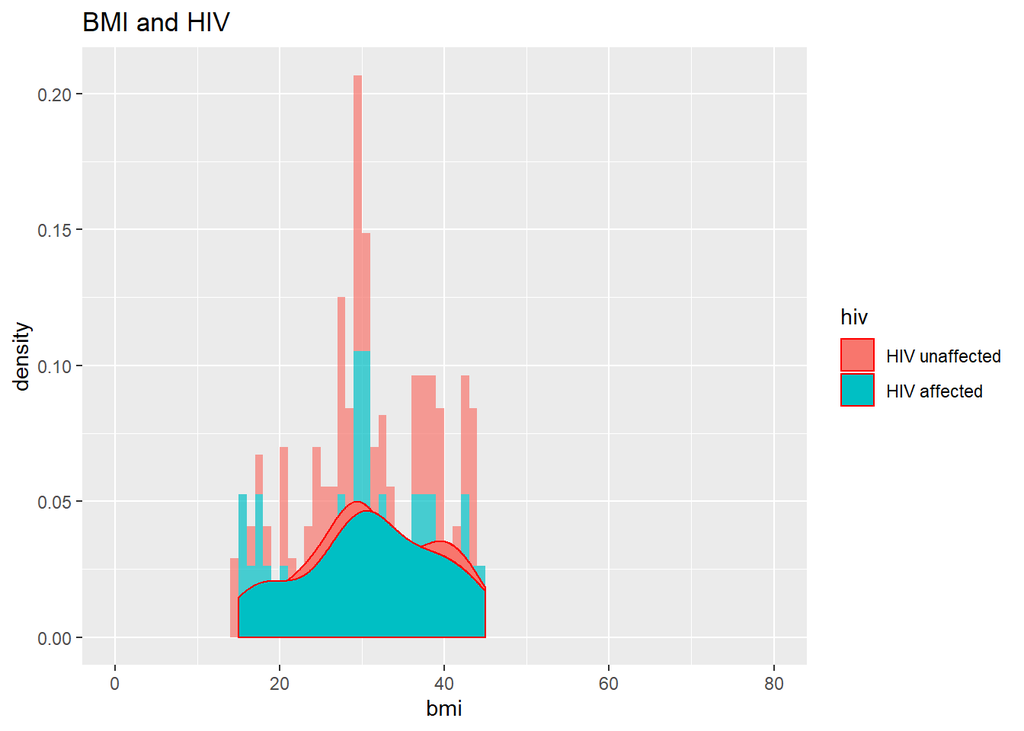

```r
ggplot(data = outcome_exposures, aes(bmi, fill=hiv)) +
    geom_histogram(aes(y = ..density..), breaks = seq(0, 80, 1),  alpha = 0.7) +
    geom_density(color = "red") +
  ggtitle(paste("BMI and HIV"))
```

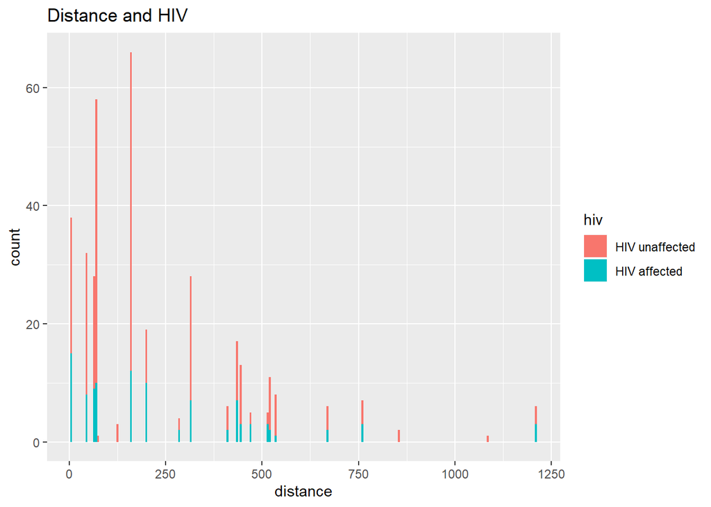

```r
ggplot(data = outcome_exposures, aes(x = distance, fill=hiv)) +
    geom_histogram(binwidth=5) +
  ggtitle(paste("Distance and HIV"))
```

```r
summary((glm(hiv ~ distance, data = outcome_exposures, family = binomial())))
```

```
##
## Call:
## glm(formula = hiv ~ distance, family = binomial(), data = outcome_exposures)
##
## Deviance Residuals:
##     Min       1Q   Median       3Q      Max
## -1.0139  -0.7972  -0.7796   1.5226   1.6522
##
## Coefficients:
##               Estimate Std. Error z value Pr(>|z|)
## (Intercept) -1.0732943  0.1632180  -6.576 4.84e-11 ***
## distance     0.0005581  0.0004768   1.171    0.242
## ---
## Signif. codes:  0 '***' 0.001 '**' 0.01 '*' 0.05 '.' 0.1 ' ' 1
##
## (Dispersion parameter for binomial family taken to be 1)
##
##     Null deviance: 431.82  on 363  degrees of freedom
## Residual deviance: 430.48  on 362  degrees of freedom
##   (3 observations deleted due to missingness)
## AIC: 434.48
##
## Number of Fisher Scoring iterations: 4
```

```r
exp(coef(glm(hiv ~ distance, data = outcome_exposures, family = binomial()))) #Odds ratio
```

```
## (Intercept)    distance
##   0.3418804   1.0005583
```

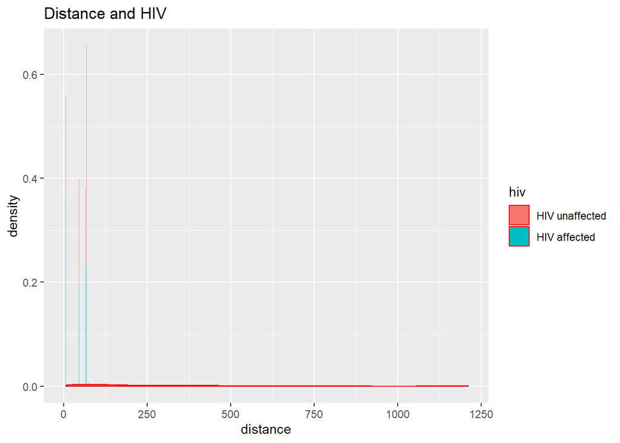

```r
ggplot(data = outcome_exposures, aes(distance, fill=hiv)) +
    geom_histogram(aes(y = ..density..), breaks = seq(0, 80, 1),  alpha = 0.7) +
    geom_density(color = "red") +
  ggtitle(paste("Distance and HIV"))
```

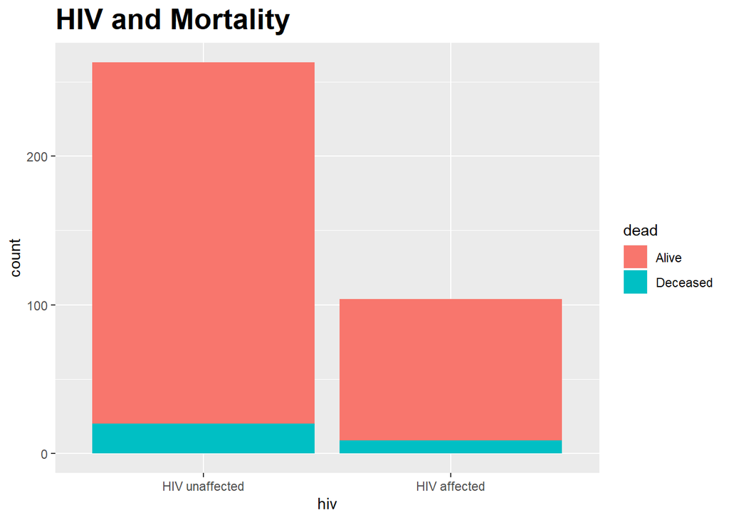

```r
ggplot(data=outcome_exposures, aes(x=hiv, fill=dead)) +
  geom_bar() +
  ggtitle(paste("HIV and Mortality")) +
  theme (
    plot.title=element_text(hjust=0, face="bold", size=20))
```

#### scatterplots

To see how two continuous variables are related to each other, age and hormone use, I used a scatterplot.

Raster of 2D density estimates I also used density plotsto help me interpret data relationships.

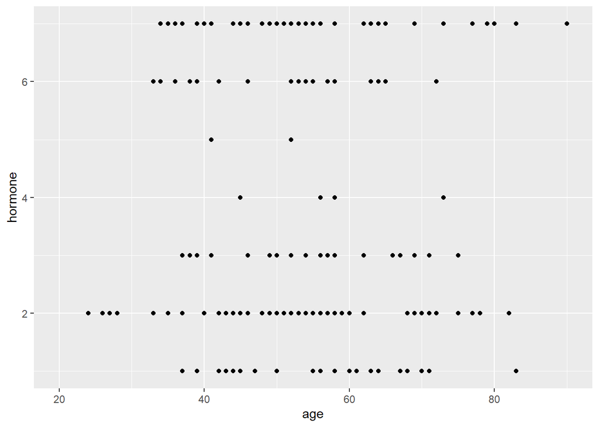

```r
#Scatterplot
ggplot(final_project_BCC, aes(x = age, y = hormone)) +
    geom_point()
```

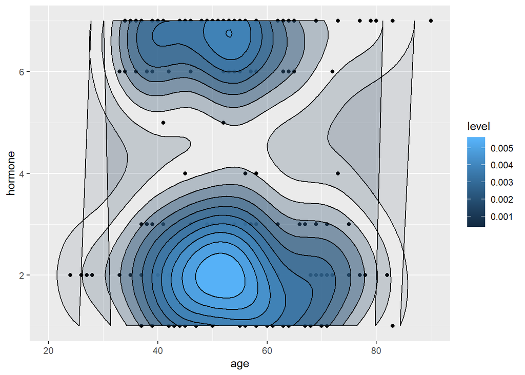

```r
# Raster of 2D density estimates
ggplot(final_project_BCC, aes(x = age, y = hormone)) +
    geom_point() +
    stat_density2d(aes(fill = ..level.., alpha = ..level..), geom = "polygon", color = "black") +
    scale_fill_continuous() +
    guides(alpha = "none")
```

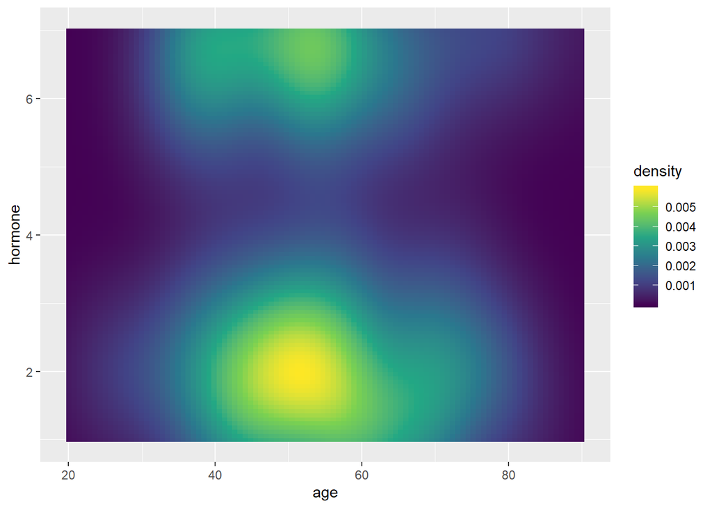

```r
#viridis` color scheme
ggplot(final_project_BCC, aes(x = age , y = hormone )) +
    stat_density2d(aes(fill = ..density..), geom = "raster", contour = FALSE) +
    scale_fill_viridis_c()
```

### Results

#### Chi-square

Here I will test univariate relationships with dichotomous and categorical variables with a Pearson’s Chi-square test and display using bar graphs.

Chi-square tests and bar plots

```r
chisq.test(table(outcome_exposures$dead, outcome_exposures$hiv))
```

```
##
##  Pearson's Chi-squared test with Yates' continuity correction
##
## data:  table(outcome_exposures$dead, outcome_exposures$hiv)
## X-squared = 0.014664, df = 1, p-value = 0.9036
```

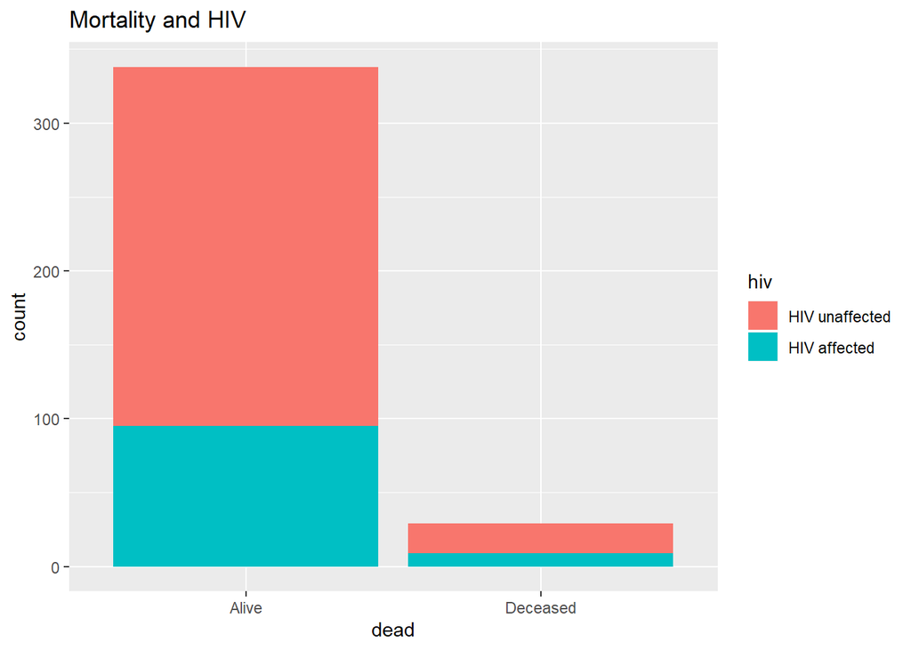

```r
ggplot(data = outcome_exposures, aes(x = dead, fill= hiv, na.rm=TRUE)) +
    geom_bar(na.rm=TRUE) +
  ggtitle(paste("Mortality and HIV"))
```

```r
chisq.test(table(outcome_exposures$dead, outcome_exposures$age_group))
```

```
##
##  Pearson's Chi-squared test
##
## data:  table(outcome_exposures$dead, outcome_exposures$age_group)
## X-squared = 4.8554, df = 2, p-value = 0.08824
```

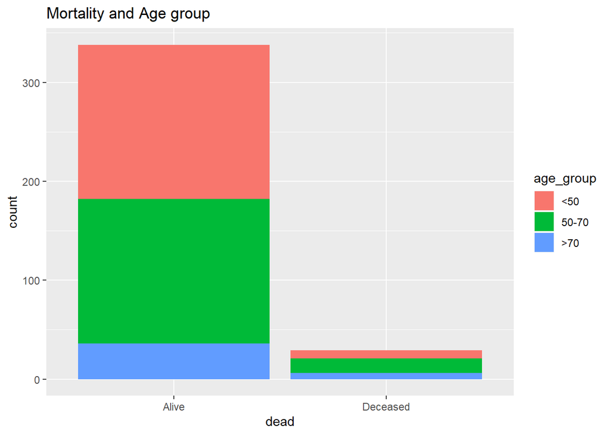

```r
ggplot(data = outcome_exposures, aes(x = dead, fill = age_group, na.rm=TRUE)) +
    geom_bar() +
  ggtitle(paste("Mortality and Age group"))
```

```r
chisq.test(table(outcome_exposures$dead, outcome_exposures$er))
```

```
##
##  Pearson's Chi-squared test with Yates' continuity correction
##
## data:  table(outcome_exposures$dead, outcome_exposures$er)
## X-squared = 0.53611, df = 1, p-value = 0.464
```

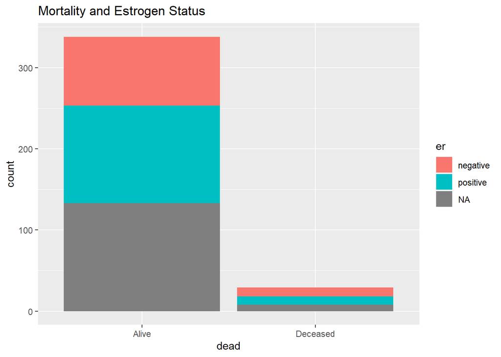

```r
ggplot(data = outcome_exposures, aes(x = dead, fill = er, na.rm=TRUE)) +
    geom_bar() +
  ggtitle(paste("Mortality and Estrogen Status"))
```

```r
chisq.test(table(outcome_exposures$dead, outcome_exposures$pr))
```

```
##
##  Pearson's Chi-squared test with Yates' continuity correction
##
## data:  table(outcome_exposures$dead, outcome_exposures$pr)
## X-squared = 3.2251, df = 1, p-value = 0.07252
```

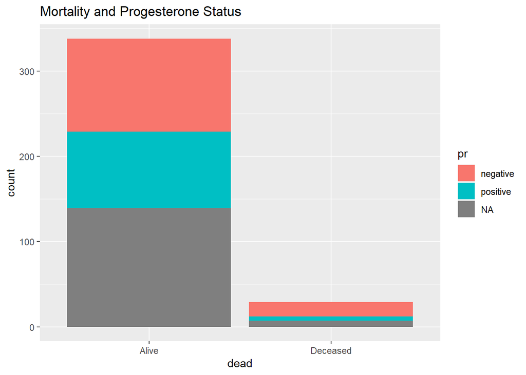

```r
ggplot(data = outcome_exposures, aes(x = dead, fill = pr, na.rm=TRUE)) +
    geom_bar() +
  ggtitle(paste("Mortality and Progesterone Status"))
```

```r
chisq.test(table(outcome_exposures$dead, outcome_exposures$her2))
```

```
##
##  Pearson's Chi-squared test with Yates' continuity correction
##
## data:  table(outcome_exposures$dead, outcome_exposures$her2)
## X-squared = 0.11293, df = 1, p-value = 0.7368
```

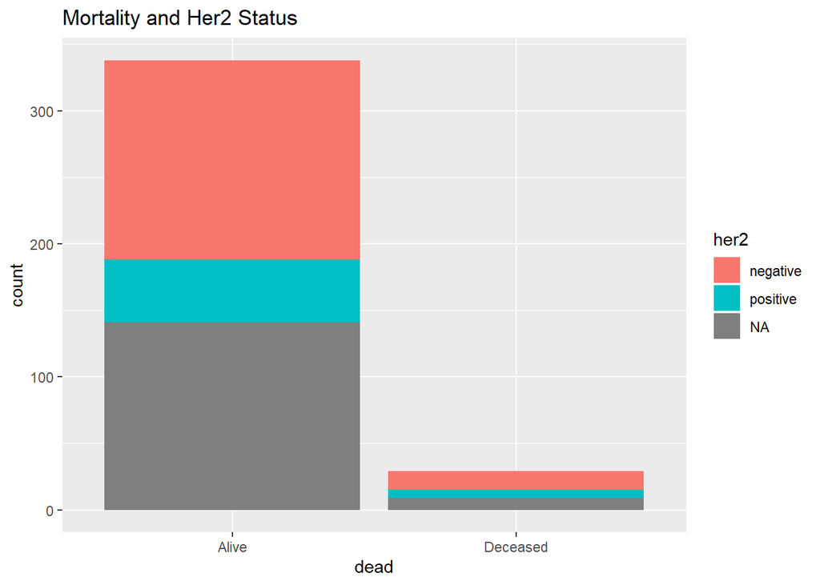

```r
ggplot(data = outcome_exposures, aes(x = dead, fill = her2, na.rm=TRUE)) +
    geom_bar() +
   ggtitle(paste("Mortality and Her2 Status"))
```

```r
chisq.test(table(outcome_exposures$dead, outcome_exposures$hormone))
```

```
##
##  Pearson's Chi-squared test
##
## data:  table(outcome_exposures$dead, outcome_exposures$hormone)
## X-squared = 9.823, df = 6, p-value = 0.1323
```

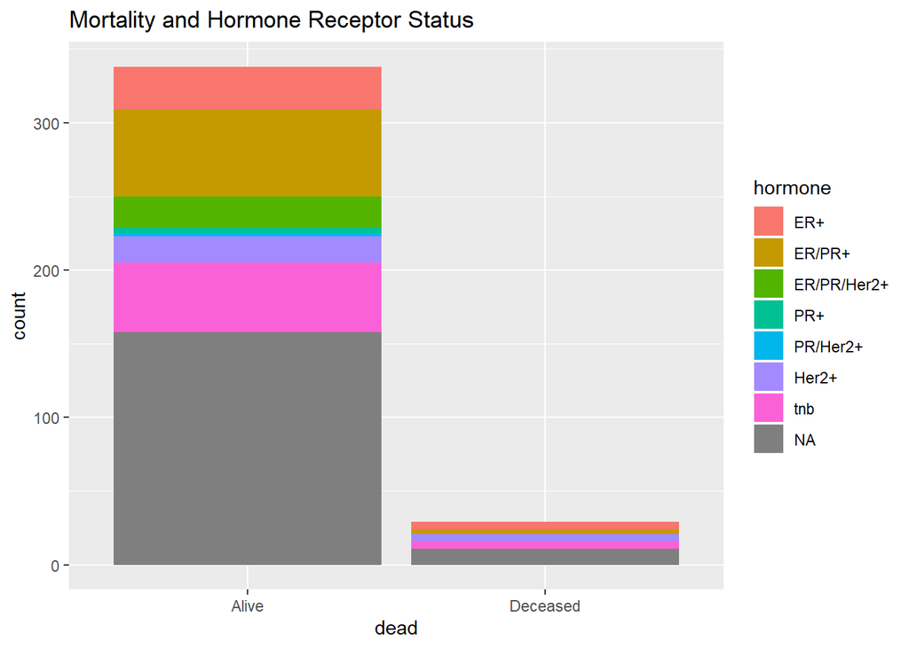

```r
ggplot(data = outcome_exposures, aes(x = dead, fill = hormone, na.rm=TRUE)) +
    geom_bar() +
   ggtitle(paste("Mortality and Hormone Receptor Status"))
```

```r
chisq.test(table(outcome_exposures$dead, outcome_exposures$marital_status))
```

```
##
##  Pearson's Chi-squared test
##
## data:  table(outcome_exposures$dead, outcome_exposures$marital_status)
## X-squared = 3.2692, df = 3, p-value = 0.352
```

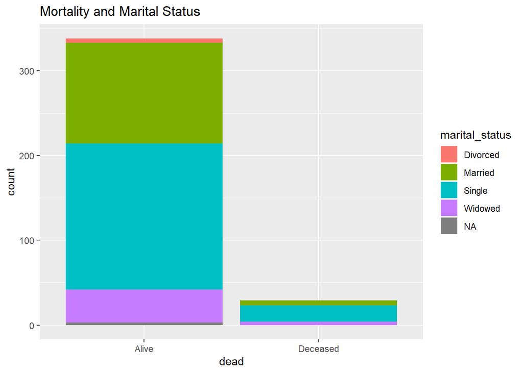

```r
ggplot(data = outcome_exposures, aes(x = dead, fill = marital_status, na.rm=TRUE)) +
    geom_bar() +
   ggtitle(paste("Mortality and Marital Status"))
```

```r
chisq.test(table(outcome_exposures$dead, outcome_exposures$smoker))
```

```
##
##  Pearson's Chi-squared test with Yates' continuity correction
##
## data:  table(outcome_exposures$dead, outcome_exposures$smoker)
## X-squared = 0.53611, df = 1, p-value = 0.464
```

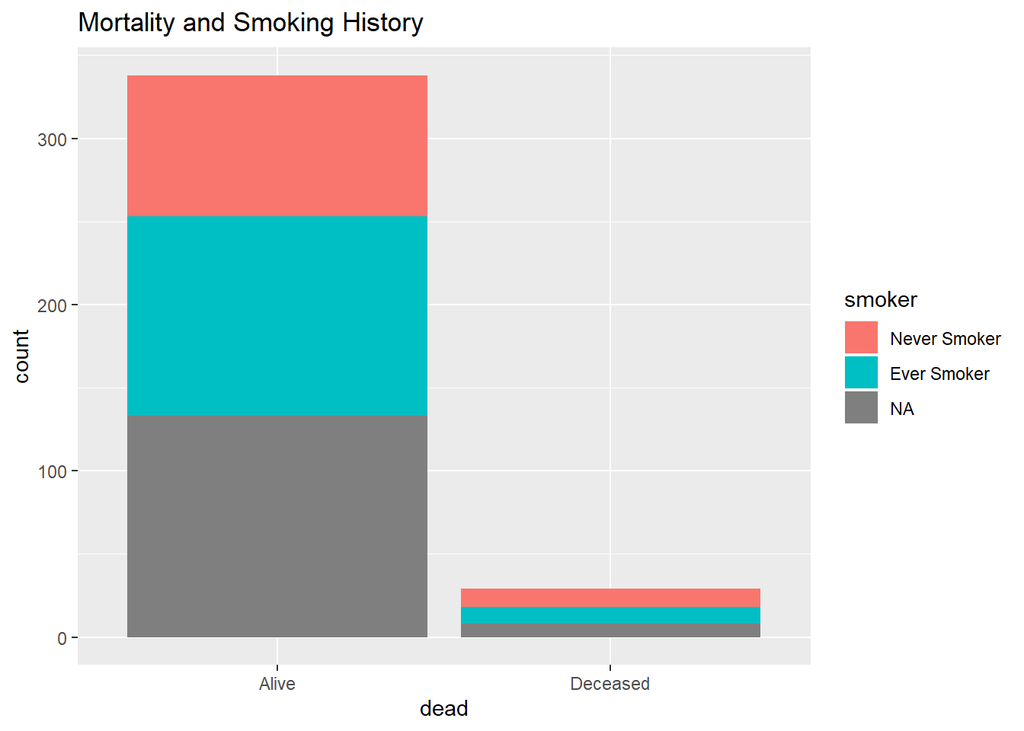

```r
ggplot(data = outcome_exposures, aes(x = dead, fill = smoker, na.rm=TRUE)) +
    geom_bar() +
   ggtitle(paste("Mortality and Smoking History"))
```

```r
chisq.test(table(outcome_exposures$dead, outcome_exposures$stage_high))
```

```
##
##  Pearson's Chi-squared test with Yates' continuity correction
##
## data:  table(outcome_exposures$dead, outcome_exposures$stage_high)
## X-squared = 1.822, df = 1, p-value = 0.1771
```

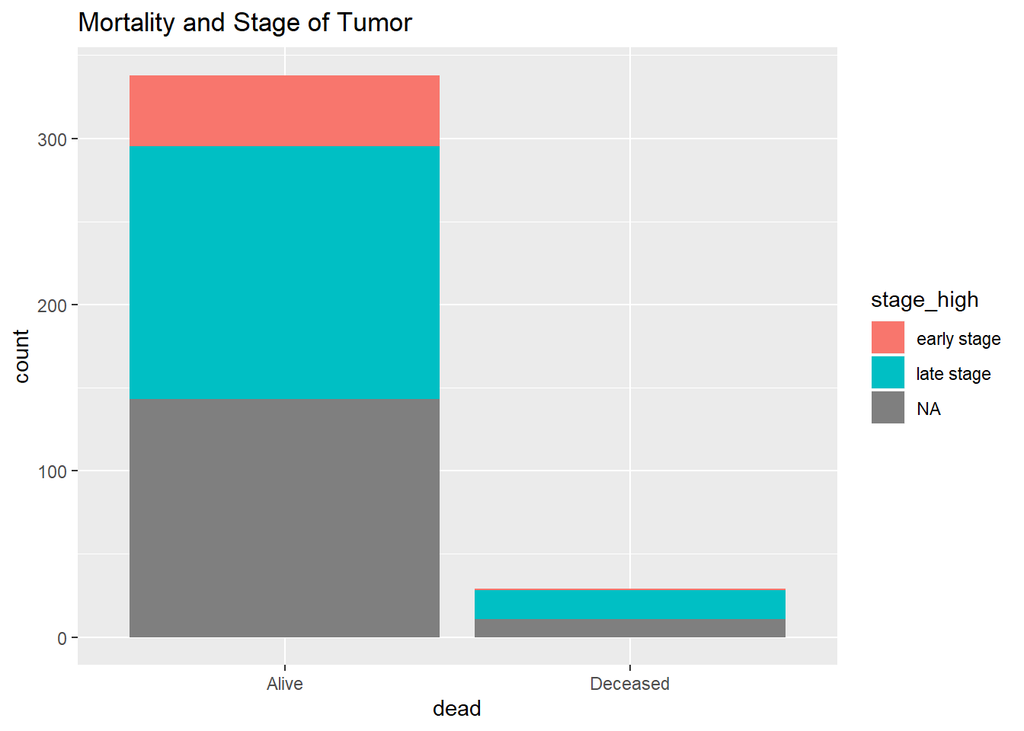

```r
ggplot(data = outcome_exposures, aes(x = dead, fill = stage_high, na.rm=TRUE)) +
    geom_bar() +
   ggtitle(paste("Mortality and Stage of Tumor"))
```

#### Univariate Logistic Regression

To fit a model to a binary outcome, I will use logistic regression with the binomial family, due to the binary outcome, as the type of function to be used for the fit. I will retrieve the summary output and also report the odds rations and 95% conifence intervals.

For the binary and categorial variables, results from Pearson’s Chi-square test and logistic regression models should be the same. I will plot the results of the continuous indepedent variables with histograms.

```r
outcome_hiv<-glm(dead ~ hiv, data=outcome_exposures, family=binomial())
summary(outcome_hiv)
```

```
##
## Call:
## glm(formula = dead ~ hiv, family = binomial(), data = outcome_exposures)
##
## Deviance Residuals:
##     Min       1Q   Median       3Q      Max
## -0.4255  -0.4255  -0.3977  -0.3977   2.2700
##
## Coefficients:
##                 Estimate Std. Error z value Pr(>|z|)
## (Intercept)      -2.4973     0.2326 -10.735   <2e-16 ***
## hivHIV affected   0.1407     0.4192   0.336    0.737
## ---
## Signif. codes:  0 '***' 0.001 '**' 0.01 '*' 0.05 '.' 0.1 ' ' 1
##
## (Dispersion parameter for binomial family taken to be 1)
##
##     Null deviance: 202.85  on 366  degrees of freedom
## Residual deviance: 202.74  on 365  degrees of freedom
## AIC: 206.74
##
## Number of Fisher Scoring iterations: 5
```

```r
exp(cbind(OR = coef(outcome_hiv), CI = confint(outcome_hiv))) #OR and 95%CI
```

```
##                         OR      2.5 %    97.5 %
## (Intercept)     0.08230453 0.05052563 0.1263776
## hivHIV affected 1.15105263 0.48335370 2.5493958
```

```r
outcome_age<-glm(dead ~ age, data=outcome_exposures, family=binomial())
summary(outcome_age)
```

```
##
## Call:
## glm(formula = dead ~ age, family = binomial(), data = outcome_exposures)
##
## Deviance Residuals:
##     Min       1Q   Median       3Q      Max
## -0.6493  -0.4354  -0.3795  -0.3303   2.5332
##
## Coefficients:
##             Estimate Std. Error z value Pr(>|z|)
## (Intercept) -4.02617    0.84792  -4.748 2.05e-06 ***
## age          0.02863    0.01448   1.977    0.048 *
## ---
## Signif. codes:  0 '***' 0.001 '**' 0.01 '*' 0.05 '.' 0.1 ' ' 1
##
## (Dispersion parameter for binomial family taken to be 1)
##
##     Null deviance: 202.85  on 366  degrees of freedom
## Residual deviance: 198.91  on 365  degrees of freedom
## AIC: 202.91
##
## Number of Fisher Scoring iterations: 5
```

```r
exp(cbind(OR = coef(outcome_age), CI = confint(outcome_age)))
```

```
##                     OR       2.5 %     97.5 %
## (Intercept) 0.01784249 0.003128389 0.08809519
## age         1.02904252 1.000375946 1.05909410
```

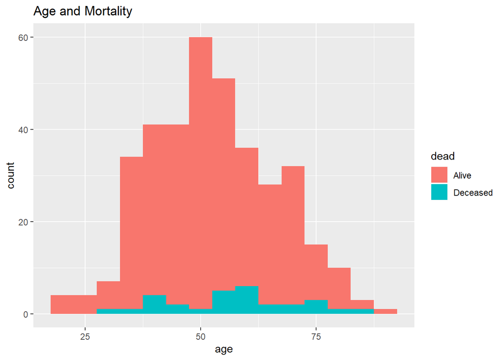

```r
ggplot(data = outcome_exposures, aes(x = age, fill=dead)) +
    geom_histogram(binwidth=5) +
  ggtitle(paste("Age and Mortality"))
```

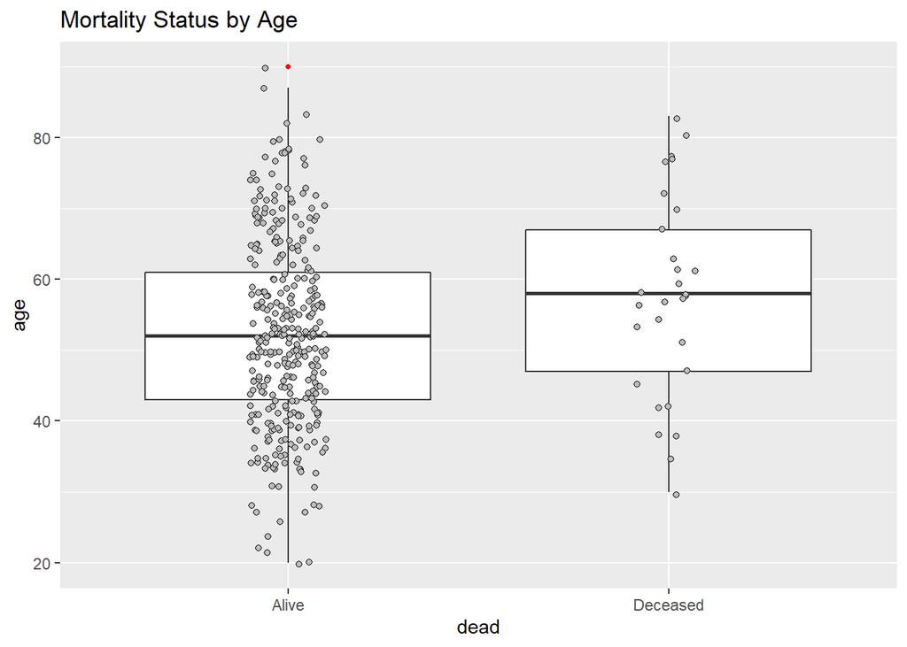

```r
ggplot(data = outcome_exposures, aes(dead, age)) +
    geom_boxplot(outlier.colour = "red", outlier.size = 1) +
  geom_jitter(width=0.1, pch=21, fill="grey", na.rm=TRUE) +
  ggtitle(paste("Mortality Status by Age"))
```

```r
outcome_age_group<-glm(dead ~ age_group, data=outcome_exposures, family=binomial())
summary(outcome_age_group)
```

```
##
## Call:
## glm(formula = dead ~ age_group, family = binomial(), data = outcome_exposures)
##
## Deviance Residuals:
##     Min       1Q   Median       3Q      Max
## -0.5553  -0.4423  -0.3163  -0.3163   2.4578
##
## Coefficients:
##                Estimate Std. Error z value Pr(>|z|)
## (Intercept)     -2.9704     0.3625  -8.195 2.51e-16 ***
## age_group50-70   0.6949     0.4527   1.535   0.1248
## age_group>70     1.1787     0.5708   2.065   0.0389 *
## ---
## Signif. codes:  0 '***' 0.001 '**' 0.01 '*' 0.05 '.' 0.1 ' ' 1
##
## (Dispersion parameter for binomial family taken to be 1)
##
##     Null deviance: 202.85  on 366  degrees of freedom
## Residual deviance: 198.14  on 364  degrees of freedom
## AIC: 204.14
##
## Number of Fisher Scoring iterations: 5
```

```r
exp(cbind(OR = coef(outcome_age_group), CI = confint(outcome_age_group)))
```

```
##                        OR      2.5 %     97.5 %
## (Intercept)    0.05128205 0.02311495 0.09755981
## age_group50-70 2.00342464 0.84431281 5.10601449
## age_group>70   3.24999997 1.01474879 9.93177625
```

```r
outcome_stage<-glm(dead ~ stage_high, data=outcome_exposures, family=binomial())
summary(outcome_stage)
```

```
##
## Call:
## glm(formula = dead ~ stage_high, family = binomial(), data = outcome_exposures)
##
## Deviance Residuals:
##     Min       1Q   Median       3Q      Max
## -0.4605  -0.4605  -0.4605  -0.2144   2.7511
##
## Coefficients:
##                      Estimate Std. Error z value Pr(>|z|)
## (Intercept)            -3.761      1.012  -3.718 0.000201 ***
## stage_highlate stage    1.571      1.043   1.505 0.132258
## ---
## Signif. codes:  0 '***' 0.001 '**' 0.01 '*' 0.05 '.' 0.1 ' ' 1
##
## (Dispersion parameter for binomial family taken to be 1)
##
##     Null deviance: 123.39  on 212  degrees of freedom
## Residual deviance: 119.86  on 211  degrees of freedom
##   (154 observations deleted due to missingness)
## AIC: 123.86
##
## Number of Fisher Scoring iterations: 6
```

```r
exp(cbind(OR = coef(outcome_stage), CI = confint(outcome_stage)))
```

```
##                              OR       2.5 %     97.5 %
## (Intercept)          0.02325581 0.001311832  0.1064841
## stage_highlate stage 4.80921052 0.945381986 87.8746172
```

```r
outcome_bmi<-glm(dead ~ bmi, data=outcome_exposures, family=binomial())
summary(outcome_bmi)
```

```
##
## Call:
## glm(formula = dead ~ bmi, family = binomial(), data = outcome_exposures)
##
## Deviance Residuals:
##     Min       1Q   Median       3Q      Max
## -0.5661  -0.4470  -0.4043  -0.3438   2.4401
##
## Coefficients:
##             Estimate Std. Error z value Pr(>|z|)
## (Intercept) -1.12053    1.33725  -0.838    0.402
## bmi         -0.04196    0.04432  -0.947    0.344
##
## (Dispersion parameter for binomial family taken to be 1)
##
##     Null deviance: 61.782  on 106  degrees of freedom
## Residual deviance: 60.876  on 105  degrees of freedom
##   (260 observations deleted due to missingness)
## AIC: 64.876
##
## Number of Fisher Scoring iterations: 5
```

```r
exp(cbind(OR = coef(outcome_bmi), CI = confint(outcome_bmi)))
```

```
##                    OR      2.5 %   97.5 %
## (Intercept) 0.3261079 0.01981362 4.107608
## bmi         0.9589113 0.87636713 1.045779
```

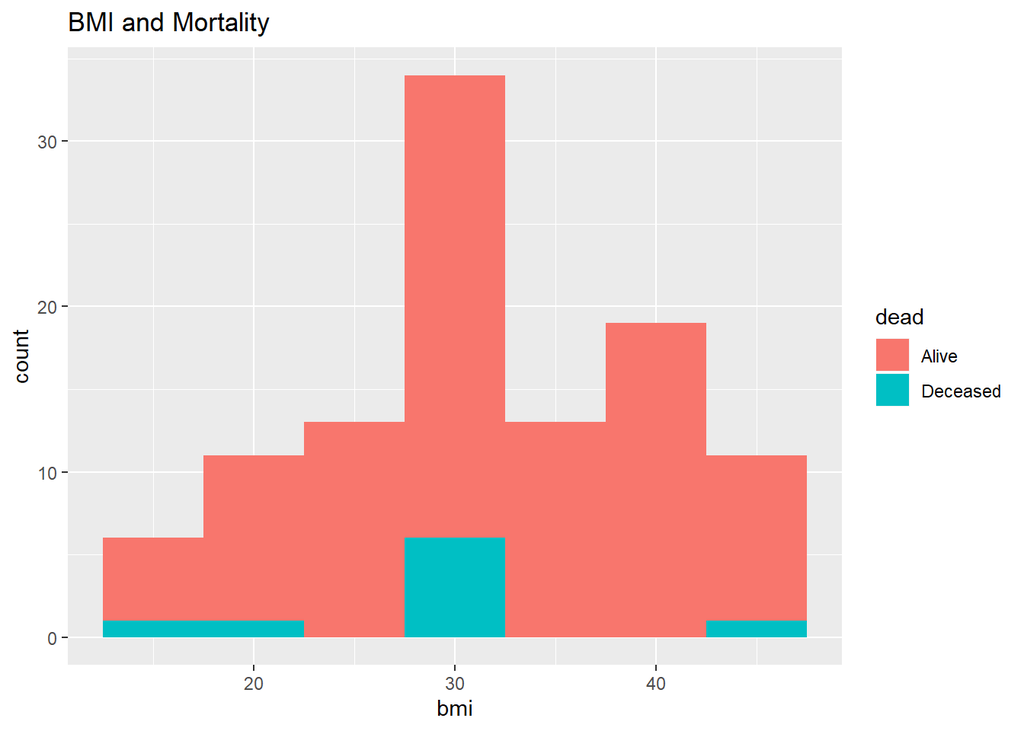

```r
ggplot(data = outcome_exposures, aes(x = bmi, fill=dead)) +
    geom_histogram(binwidth=5) +
  ggtitle(paste("BMI and Mortality"))
```

```r
outcome_hormone<-glm(dead ~ hormone, data=outcome_exposures, family=binomial())
summary(outcome_hormone)
```

```
##
## Call:
## glm(formula = dead ~ hormone, family = binomial(), data = outcome_exposures)
##
## Deviance Residuals:
##     Min       1Q   Median       3Q      Max
## -0.7002  -0.4497  -0.3150  -0.3150   2.4611
##
## Coefficients:
##                     Estimate Std. Error z value Pr(>|z|)
## (Intercept)          -1.7579     0.4842  -3.630 0.000283 ***
## hormoneER/PR+        -1.2211     0.7647  -1.597 0.110312
## hormoneER/PR/Her2+  -16.8082  1423.3565  -0.012 0.990578
## hormonePR+          -16.8082  3261.3193  -0.005 0.995888
## hormonePR/Her2+     -16.8082  4612.2020  -0.004 0.997092
## hormoneHer2+          0.4769     0.7000   0.681 0.495686
## hormonetnb           -0.4829     0.6751  -0.715 0.474467
## ---
## Signif. codes:  0 '***' 0.001 '**' 0.01 '*' 0.05 '.' 0.1 ' ' 1
##
## (Dispersion parameter for binomial family taken to be 1)
##
##     Null deviance: 120.64  on 197  degrees of freedom
## Residual deviance: 109.42  on 191  degrees of freedom
##   (169 observations deleted due to missingness)
## AIC: 123.42
##
## Number of Fisher Scoring iterations: 17
```

```r
exp(cbind(OR = coef(outcome_hormone), CI = confint(outcome_hormone)))
```

[output not shown]

[output cut: 38 more lines]

[output not shown]

```
##                              OR      2.5 %        97.5 %
## (Intercept)        1.724138e-01 0.05865478  4.081144e-01
## hormoneER/PR+      2.949153e-01 0.05726035  1.284570e+00
## hormoneER/PR/Her2+ 5.015184e-08         NA  3.440324e+31
## hormonePR+         5.015184e-08         NA 1.044450e+153
## hormonePR/Her2+    5.015184e-08         NA 9.355124e+305
## hormoneHer2+       1.611111e+00 0.39714652  6.564516e+00
## hormonetnb         6.170213e-01 0.15874017  2.394076e+00
```

```r
outcome_er<-glm(dead ~ er, data=outcome_exposures, family=binomial())
summary(outcome_er)
```

```
##
## Call:
## glm(formula = dead ~ er, family = binomial(), data = outcome_exposures)
##
## Deviance Residuals:
##     Min       1Q   Median       3Q      Max
## -0.4934  -0.4934  -0.4001  -0.4001   2.2649
##
## Coefficients:
##             Estimate Std. Error z value Pr(>|z|)
## (Intercept)  -2.0448     0.3204  -6.381 1.76e-10 ***
## erpositive   -0.4402     0.4594  -0.958    0.338
## ---
## Signif. codes:  0 '***' 0.001 '**' 0.01 '*' 0.05 '.' 0.1 ' ' 1
##
## (Dispersion parameter for binomial family taken to be 1)
##
##     Null deviance: 139.78  on 225  degrees of freedom
## Residual deviance: 138.86  on 224  degrees of freedom
##   (141 observations deleted due to missingness)
## AIC: 142.86
##
## Number of Fisher Scoring iterations: 5
```

```r
exp(cbind(OR = coef(outcome_er), CI = confint(outcome_er)))
```

```
##                    OR      2.5 %    97.5 %
## (Intercept) 0.1294118 0.06520631 0.2318347
## erpositive  0.6439394 0.25730170 1.5936378
```

```r
outcome_pr<-glm(dead ~ pr, data=outcome_exposures, family=binomial())
summary(outcome_pr)
```

```
##
## Call:
## glm(formula = dead ~ pr, family = binomial(), data = outcome_exposures)
##
## Deviance Residuals:
##     Min       1Q   Median       3Q      Max
## -0.5384  -0.5384  -0.3288  -0.3288   2.4267
##
## Coefficients:
##             Estimate Std. Error z value Pr(>|z|)
## (Intercept)  -1.8581     0.2608  -7.126 1.04e-12 ***
## prpositive   -1.0322     0.5283  -1.954   0.0507 .
## ---
## Signif. codes:  0 '***' 0.001 '**' 0.01 '*' 0.05 '.' 0.1 ' ' 1
##
## (Dispersion parameter for binomial family taken to be 1)
##
##     Null deviance: 143.25  on 220  degrees of freedom
## Residual deviance: 138.88  on 219  degrees of freedom
##   (146 observations deleted due to missingness)
## AIC: 142.88
##
## Number of Fisher Scoring iterations: 5
```

```r
exp(cbind(OR = coef(outcome_pr), CI = confint(outcome_pr)))
```

```
##                    OR      2.5 %    97.5 %
## (Intercept) 0.1559633 0.09030828 0.2526455
## prpositive  0.3562092 0.11354026 0.9404315
```

```r
outcome_her2<-glm(dead ~ her2, data=outcome_exposures, family=binomial())
summary(outcome_her2)
```

```
##
## Call:
## glm(formula = dead ~ her2, family = binomial(), data = outcome_exposures)
##
## Deviance Residuals:
##     Min       1Q   Median       3Q      Max
## -0.4902  -0.4224  -0.4224  -0.4224   2.2185
##
## Coefficients:
##              Estimate Std. Error z value Pr(>|z|)
## (Intercept)   -2.3716     0.2795  -8.486   <2e-16 ***
## her2positive   0.3132     0.5158   0.607    0.544
## ---
## Signif. codes:  0 '***' 0.001 '**' 0.01 '*' 0.05 '.' 0.1 ' ' 1
##
## (Dispersion parameter for binomial family taken to be 1)
##
##     Null deviance: 133.46  on 216  degrees of freedom
## Residual deviance: 133.11  on 215  degrees of freedom
##   (150 observations deleted due to missingness)
## AIC: 137.11
##
## Number of Fisher Scoring iterations: 5
```

```r
exp(cbind(OR = coef(outcome_her2), CI = confint(outcome_her2)))
```

```
##                      OR      2.5 %    97.5 %
## (Intercept)  0.09333333 0.05154342 0.1554486
## her2positive 1.36778116 0.46278354 3.6190820
```

```r
outcome_marital<-glm(dead ~ marital_status, data=outcome_exposures, family=binomial())
summary(outcome_marital)
```

```
##
## Call:
## glm(formula = dead ~ marital_status, family = binomial(), data = outcome_exposures)
##
## Deviance Residuals:
##     Min       1Q   Median       3Q      Max
## -0.4578  -0.4578  -0.4419  -0.3137   2.4644
##
## Coefficients:
##                       Estimate Std. Error z value Pr(>|z|)
## (Intercept)             -16.57    1073.11  -0.015    0.988
## marital_statusMarried    13.58    1073.11   0.013    0.990
## marital_statusSingle     14.36    1073.11   0.013    0.989
## marital_statusWidowed    14.29    1073.11   0.013    0.989
##
## (Dispersion parameter for binomial family taken to be 1)
##
##     Null deviance: 202.36  on 363  degrees of freedom
## Residual deviance: 198.50  on 360  degrees of freedom
##   (3 observations deleted due to missingness)
## AIC: 206.5
##
## Number of Fisher Scoring iterations: 15
```

```r
exp(cbind(OR = coef(outcome_marital), CI = confint(outcome_marital)))
```

[output not shown]

[output cut: 24 more lines]

[output not shown]

```
##                                 OR        2.5 %        97.5 %
## (Intercept)           6.389221e-08           NA  1.671650e+41
## marital_statusMarried 7.891442e+05 1.428329e-42            NA
## marital_statusSingle  1.728929e+06 8.374438e-43            NA
## marital_statusWidowed 1.605268e+06 6.250019e-19 3.492934e+111
```

```r
outcome_distance<-glm(dead ~ distance, data=outcome_exposures, family=binomial())
summary(outcome_distance)
```

```
##
## Call:
## glm(formula = dead ~ distance, family = binomial(), data = outcome_exposures)
##
## Deviance Residuals:
##     Min       1Q   Median       3Q      Max
## -0.4346  -0.4265  -0.4141  -0.3796   2.5076
##
## Coefficients:
##               Estimate Std. Error z value Pr(>|z|)
## (Intercept) -2.3082043  0.2670189  -8.644   <2e-16 ***
## distance    -0.0006538  0.0009251  -0.707     0.48
## ---
## Signif. codes:  0 '***' 0.001 '**' 0.01 '*' 0.05 '.' 0.1 ' ' 1
##
## (Dispersion parameter for binomial family taken to be 1)
##
##     Null deviance: 202.36  on 363  degrees of freedom
## Residual deviance: 201.82  on 362  degrees of freedom
##   (3 observations deleted due to missingness)
## AIC: 205.82
##
## Number of Fisher Scoring iterations: 5
```

```r
exp(cbind(OR = coef(outcome_distance), CI = confint(outcome_distance)))
```

```
##                     OR      2.5 %    97.5 %
## (Intercept) 0.09943965 0.05758329 0.1645818
## distance    0.99934642 0.99732513 1.0009835
```

```r
outcome_smoker<-glm(dead ~ smoker, data=outcome_exposures, family=binomial())
summary(outcome_smoker)
```

```
##
## Call:
## glm(formula = dead ~ smoker, family = binomial(), data = outcome_exposures)
##
## Deviance Residuals:
##     Min       1Q   Median       3Q      Max
## -0.4934  -0.4934  -0.4001  -0.4001   2.2649
##
## Coefficients:
##                   Estimate Std. Error z value Pr(>|z|)
## (Intercept)        -2.0448     0.3204  -6.381 1.76e-10 ***
## smokerEver Smoker  -0.4402     0.4594  -0.958    0.338
## ---
## Signif. codes:  0 '***' 0.001 '**' 0.01 '*' 0.05 '.' 0.1 ' ' 1
##
## (Dispersion parameter for binomial family taken to be 1)
##
##     Null deviance: 139.78  on 225  degrees of freedom
## Residual deviance: 138.86  on 224  degrees of freedom
##   (141 observations deleted due to missingness)
## AIC: 142.86
##
## Number of Fisher Scoring iterations: 5
```

```r
exp(cbind(OR = coef(outcome_smoker), CI = confint(outcome_smoker)))
```

```
##                          OR      2.5 %    97.5 %
## (Intercept)       0.1294118 0.06520631 0.2318347
## smokerEver Smoker 0.6439394 0.25730170 1.5936378
```

#### Multivariate Logistic Regression

```r
all_hiv<- outcome_exposures %>%
  select("hiv", "age", "stage_high", "pr", "dead")
outcome_all_hiv<-glm(dead ~ ., data=all_hiv, family=binomial())
summary(outcome_all_hiv)
```

```
##
## Call:
## glm(formula = dead ~ ., family = binomial(), data = all_hiv)
##
## Deviance Residuals:
##     Min       1Q   Median       3Q      Max
## -0.7465  -0.5063  -0.4034  -0.2893   2.6040
##
## Coefficients:
##                      Estimate Std. Error z value Pr(>|z|)
## (Intercept)          -4.78883    1.70075  -2.816  0.00487 **
## hivHIV affected       0.72824    0.63393   1.149  0.25065
## age                   0.02517    0.02271   1.108  0.26765
## stage_highlate stage  1.28883    1.06339   1.212  0.22551
## prpositive           -0.37977    0.59633  -0.637  0.52422
## ---
## Signif. codes:  0 '***' 0.001 '**' 0.01 '*' 0.05 '.' 0.1 ' ' 1
##
## (Dispersion parameter for binomial family taken to be 1)
##
##     Null deviance: 92.057  on 144  degrees of freedom
## Residual deviance: 87.642  on 140  degrees of freedom
##   (222 observations deleted due to missingness)
## AIC: 97.642
##
## Number of Fisher Scoring iterations: 6
```

```r
exp(cbind(OR = coef(outcome_all_hiv), CI = confint(outcome_all_hiv)))
```

```
##                               OR        2.5 %    97.5 %
## (Intercept)          0.008322181 0.0001832429  0.178122
## hivHIV affected      2.071441229 0.5648594232  7.136236
## age                  1.025494125 0.9811192347  1.073712
## stage_highlate stage 3.628545487 0.6691145352 67.575005
## prpositive           0.684016460 0.1966427550  2.137590
```

```r
all<- outcome_exposures %>%
  select("age", "stage_high", "pr", "dead")
outcome_all<-glm(dead ~ ., data=all, family=binomial())
summary(outcome_all)
```

```
##
## Call:
## glm(formula = dead ~ ., family = binomial(), data = all)
##
## Deviance Residuals:
##     Min       1Q   Median       3Q      Max
## -0.6628  -0.5124  -0.4498  -0.2823   2.5660
##
## Coefficients:
##                      Estimate Std. Error z value Pr(>|z|)
## (Intercept)          -4.22112    1.59705  -2.643  0.00822 **
## age                   0.01818    0.02135   0.851  0.39454
## stage_highlate stage  1.30828    1.06211   1.232  0.21803
## prpositive           -0.34214    0.59206  -0.578  0.56334
## ---
## Signif. codes:  0 '***' 0.001 '**' 0.01 '*' 0.05 '.' 0.1 ' ' 1
##
## (Dispersion parameter for binomial family taken to be 1)
##
##     Null deviance: 92.057  on 144  degrees of freedom
## Residual deviance: 88.909  on 141  degrees of freedom
##   (222 observations deleted due to missingness)
## AIC: 96.909
##
## Number of Fisher Scoring iterations: 6
```

```r
exp(cbind(OR = coef(outcome_all), CI = confint(outcome_all)))
```

```
##                              OR        2.5 %     97.5 %
## (Intercept)          0.01468221 0.0003841327  0.2581191
## age                  1.01834696 0.9763448081  1.0627352
## stage_highlate stage 3.69980465 0.6856543099 68.8266097
## prpositive           0.71024781 0.2058716197  2.2024823
```

```r
outcome_all<-glm(dead ~ ., data=all, family=binomial())
summary(outcome_all)
```

```
##
## Call:
## glm(formula = dead ~ ., family = binomial(), data = all)
##
## Deviance Residuals:
##     Min       1Q   Median       3Q      Max
## -0.6628  -0.5124  -0.4498  -0.2823   2.5660
##
## Coefficients:
##                      Estimate Std. Error z value Pr(>|z|)
## (Intercept)          -4.22112    1.59705  -2.643  0.00822 **
## age                   0.01818    0.02135   0.851  0.39454
## stage_highlate stage  1.30828    1.06211   1.232  0.21803
## prpositive           -0.34214    0.59206  -0.578  0.56334
## ---
## Signif. codes:  0 '***' 0.001 '**' 0.01 '*' 0.05 '.' 0.1 ' ' 1
##
## (Dispersion parameter for binomial family taken to be 1)
##
##     Null deviance: 92.057  on 144  degrees of freedom
## Residual deviance: 88.909  on 141  degrees of freedom
##   (222 observations deleted due to missingness)
## AIC: 96.909
##
## Number of Fisher Scoring iterations: 6
```

```r
exp(cbind(OR = coef(outcome_all), CI = confint(outcome_all)))
```

```
##                              OR        2.5 %     97.5 %
## (Intercept)          0.01468221 0.0003841327  0.2581191
## age                  1.01834696 0.9763448081  1.0627352
## stage_highlate stage 3.69980465 0.6856543099 68.8266097
## prpositive           0.71024781 0.2058716197  2.2024823
```

```r
outcome<-glm(dead ~ hiv+ age + pr, data=outcome_exposures, family=binomial())
summary(outcome)
```

```
##
## Call:
## glm(formula = dead ~ hiv + age + pr, family = binomial(), data = outcome_exposures)
##
## Deviance Residuals:
##     Min       1Q   Median       3Q      Max
## -0.8857  -0.5081  -0.3918  -0.2815   2.6788
##
## Coefficients:
##                 Estimate Std. Error z value Pr(>|z|)
## (Intercept)     -4.24527    1.21650  -3.490 0.000484 ***
## hivHIV affected  0.69838    0.53525   1.305 0.191974
## age              0.03902    0.01926   2.026 0.042775 *
## prpositive      -1.07051    0.53470  -2.002 0.045277 *
## ---
## Signif. codes:  0 '***' 0.001 '**' 0.01 '*' 0.05 '.' 0.1 ' ' 1
##
## (Dispersion parameter for binomial family taken to be 1)
##
##     Null deviance: 143.25  on 220  degrees of freedom
## Residual deviance: 134.12  on 217  degrees of freedom
##   (146 observations deleted due to missingness)
## AIC: 142.12
##
## Number of Fisher Scoring iterations: 5
```

### Botswana Shape File

#### Spatial Data and Mapping

Mapping a Botswana Shape file- but no data at this time to converge. This turned out to be more difficult than I anticipated because there are not a lot of avaiabe files for geogrpahy and Botswana. Also, there are no FIPs codes or census blocks to merge data sets. This is something I would like to explore further as I appreciated the geographic capabilties of R with spatial data.

```r
library(sp)
library(rgdal)
library(sf)
dir.create("Bostwana")
setwd("Bostwana")
shape <- readOGR(dsn = ".", layer = "BWA_adm2")
```

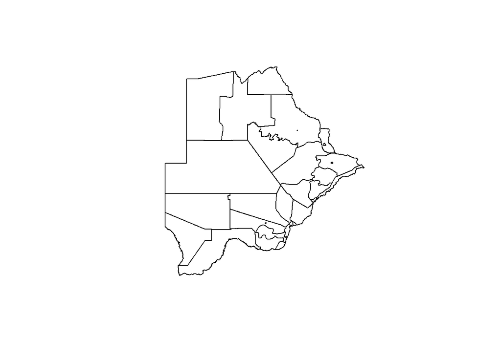

```r
plot(shape)
```

### Conclusion

Also, future directions for this area of research includes learning information that can be applicable to other cancers, informing policy about the need for breast cancer screening programs, and lessons learned from this can be applied to other LMICs.